# Chapter 4

I could not get the arrows work, so I had to result in … more libraries. sigh.

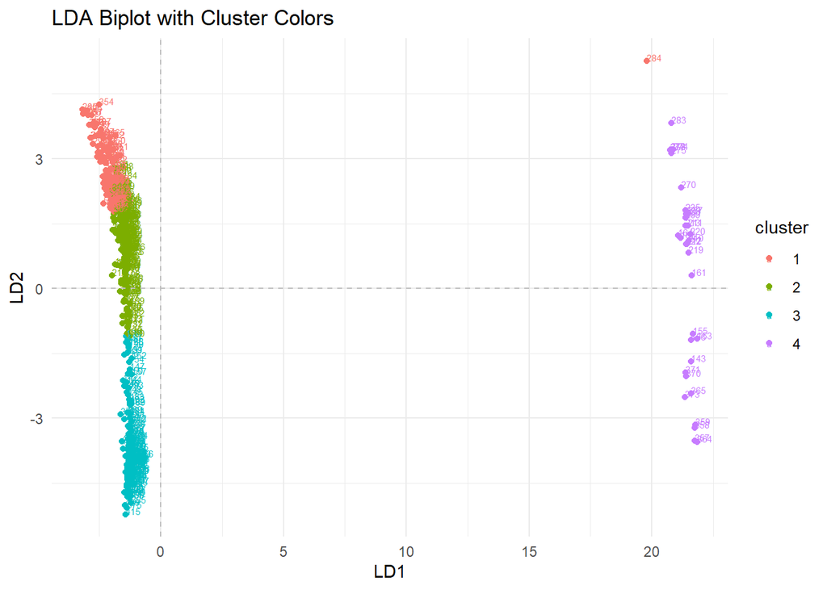

```r
library(cluster)  # for kmeans function
library(ggplot2)  # for data visualization

# Load the Boston dataset
data("Boston")
df_boston <- Boston

# Standardize the data
scaled_data <- scale(df_boston)

# Choose the number of clusters
k <- 4

# Run k-means clustering
kmeans_result <- kmeans(scaled_data, centers = k, nstart = 25)

# Add cluster assignments to the original dataset
df_boston$cluster <- as.factor(kmeans_result$cluster)

# Run Linear Discriminant Analysis (LDA)
lda_result <- lda(cluster ~ ., data = df_boston)

# Extract LDA results
lda_data <- predict(lda_result)

# Combine original data with LDA results
df_lda <- cbind(df_boston, as.data.frame(lda_data$x))

# Create a biplot using ggplot2
ggplot(df_lda, aes(x = LD1, y = LD2, color = cluster)) +
  geom_point() +
  geom_text(aes(label = row.names(df_boston)), hjust = 0, vjust = 0, size = 2) +
  geom_hline(yintercept = 0, linetype = "dashed", color = "gray") +
  geom_vline(xintercept = 0, linetype = "dashed", color = "gray") +
  labs(title = "LDA Biplot with Cluster Colors") +
  theme_minimal()
```

I for one cannot make the arrows appear. How about:

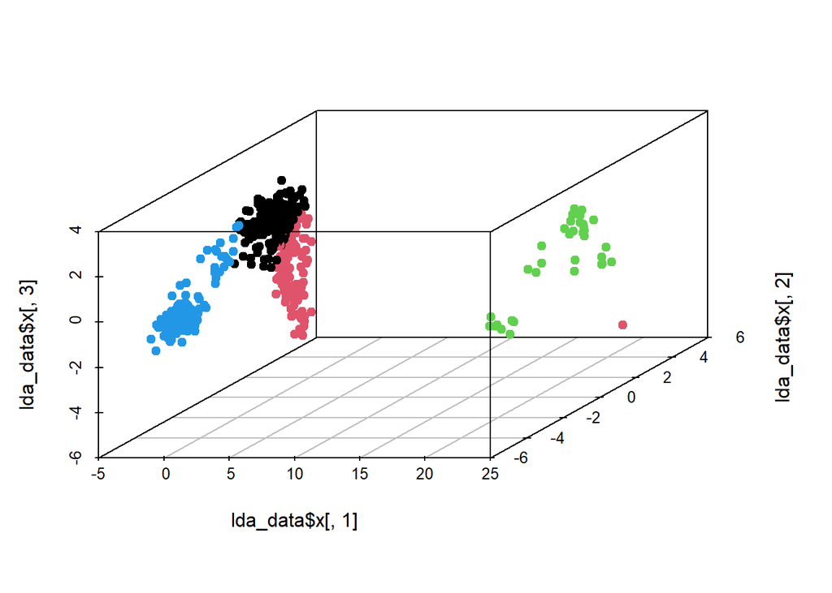

```r
library(scatterplot3d)

# Load the Boston dataset
data("Boston")
df_boston <- Boston

# Standardize the data
scaled_data <- scale(df_boston)

# Choose the number of clusters (e.g., k = 4)
k <- 4

# Run k-means clustering
kmeans_result <- kmeans(scaled_data, centers = k, nstart = 25)

# Add cluster assignments to the original dataset
df_boston$cluster <- as.factor(kmeans_result$cluster)

# Run Linear Discriminant Analysis (LDA)
lda_result <- lda(cluster ~ ., data = df_boston)

# Extract LDA results
lda_data <- predict(lda_result)

# Create a 3D scatter plot with arrows
scatterplot3d(lda_data$x[, 1], lda_data$x[, 2], lda_data$x[, 3], color = df_boston$cluster, pch = 19)
```

No. All kinds of arrows are simply off limits for me today Anyways, in this plot we can see as badly as from the 2D plot, that points on the left side LD1 cluster are tightly clumped and are separated from each other mainly on the LD2 axis. Then we have a single cluster on the other side of LD1 axis that spans widely across LD2. The position of the point along the LD1 and LD2 axes indicates the values of that observation in the two linear discriminant dimensions. Points that are closer together tend to be more similar in terms of the linear discriminant dimensions. (Each point is colored based on its assigned cluster from the k-means clustering.)

Oh wait

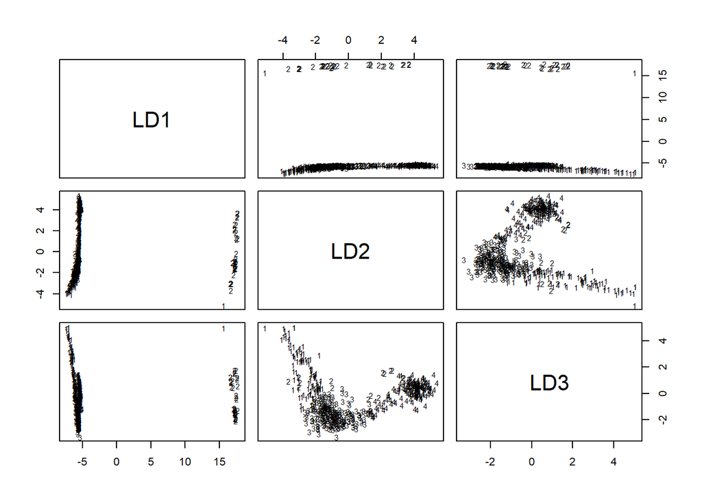

```r
# Load the Boston dataset
data("Boston")
df_boston <- Boston

# Standardize the data
scaled_data <- scale(df_boston)

# Choose the number of clusters
k <- 4

# Run k-means clustering
kmeans_result <- kmeans(scaled_data, centers = k, nstart = 25)

# Add cluster assignments to the original dataset
df_boston$cluster <- as.factor(kmeans_result$cluster)

# Run Linear Discriminant Analysis (LDA)
lda_result <- lda(cluster ~ ., data = df_boston)

# Extract LDA results
lda_data <- predict(lda_result)

# Create a biplot using the plot() function
plot(lda_result)
```

No. I give up. I would like arrows in graphs, not in my knee. Perhaps I should have stuck to less linear discriminant and effectively copied from the exercise, but that did not seem very educational.